# Confidence intervals

## Recap on bias assessment

- Let’s do some more practice on computing bias using simulations and analytically.
- Consider the NSDUH data where the probability of the event is small.
- E.g. few people in the population have used PCP

```r
set.seed(555)
puf = readRDS('../datasets/nsduh/puf.rds')
pcptab = table( puf$pcpflag)
pcptab/sum(pcptab)
```

```
##
##         no        yes
## 0.98537708 0.01462292
```

```r
n = 50
# all "no"s
pcpsamp = sample(puf$pcpflag, size = n)

pcpsamp
```

```
##  [1] no no no no no no no no no no no no no no no no no no no no no no no no no
## [26] no no no no no no no no no no no no no no no no no no no no no no no no no
## Levels: no yes
```

- In cases like this, sometimes people recommend using a modified estimator of $p$,
  $$\tilde p = \frac{\sum_{i=1}^n X_i + 1/2}{n + 1},$$
  which adds 1/2 observation to the “yes” category and 1/2 observation to the “no” category.
- What is expected value of $\tilde p$?
- Plot the bias of $\tilde p$.

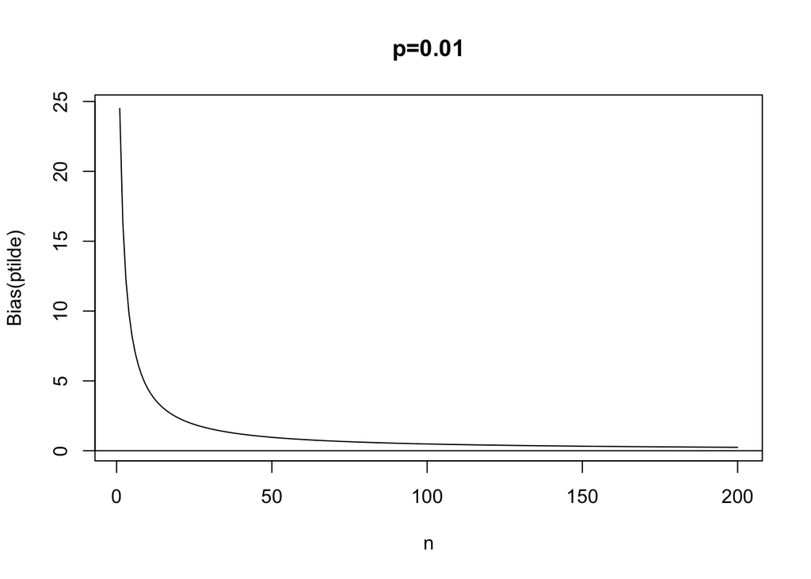

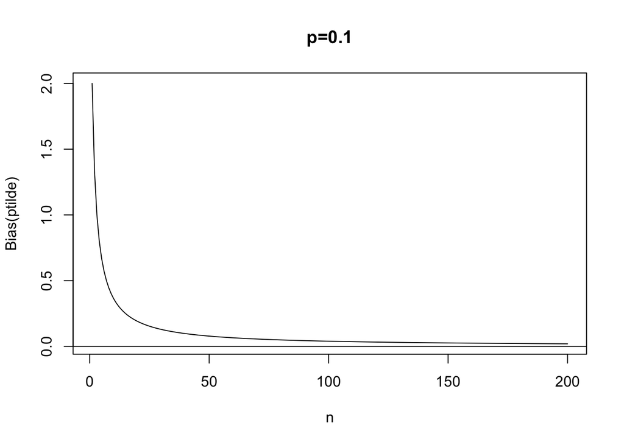

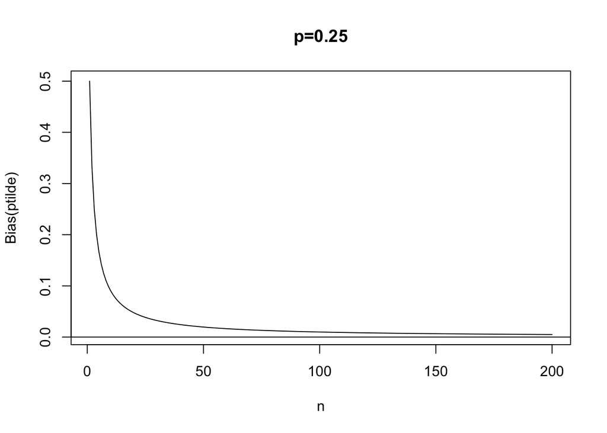

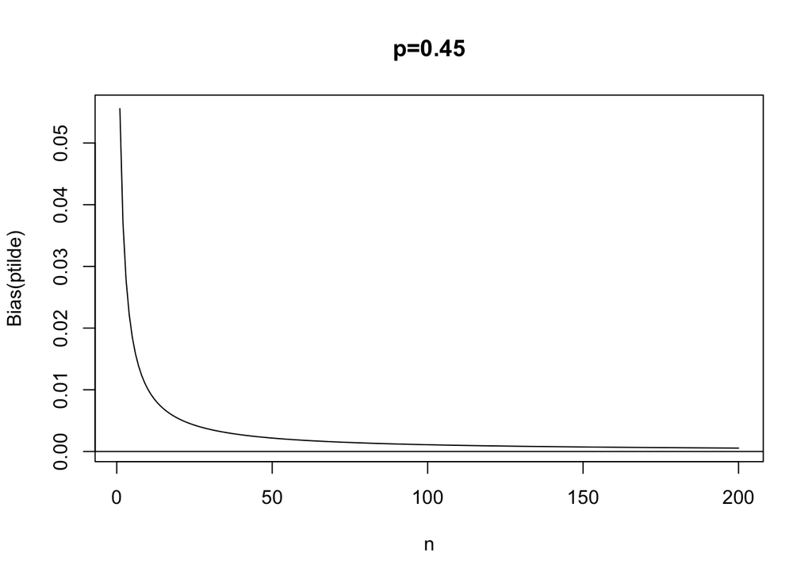

```r
n = 1:200
ps = c(0.01, 0.1, 0.25, 0.45)
for(p in ps){
  ptildeBias = (n * p + 0.5)/(n+1) - p
  # remove y-axis limits to rescale
  # divide by p for percent bias
  plot(n, ptildeBias/p, xlab='n', ylab='Bias(ptilde)', type='l', main=paste0('p=',p) )
  abline(h=0)
}
```

We can also run simulations to assess the bias and the curves should agree with the results that we found in the other plots.

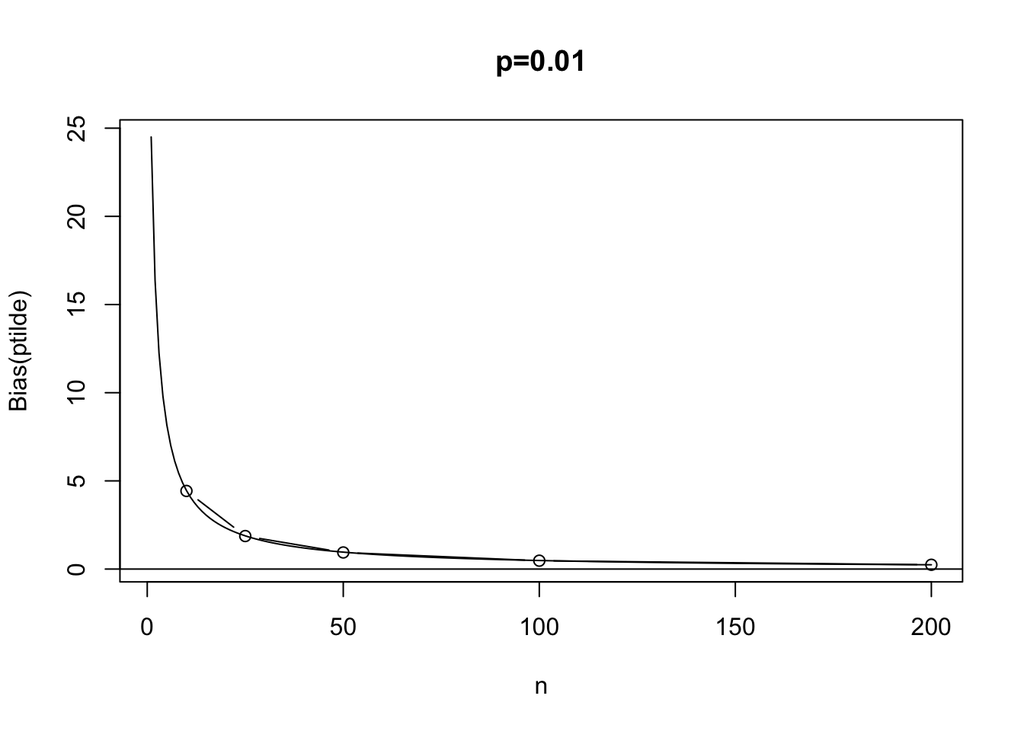

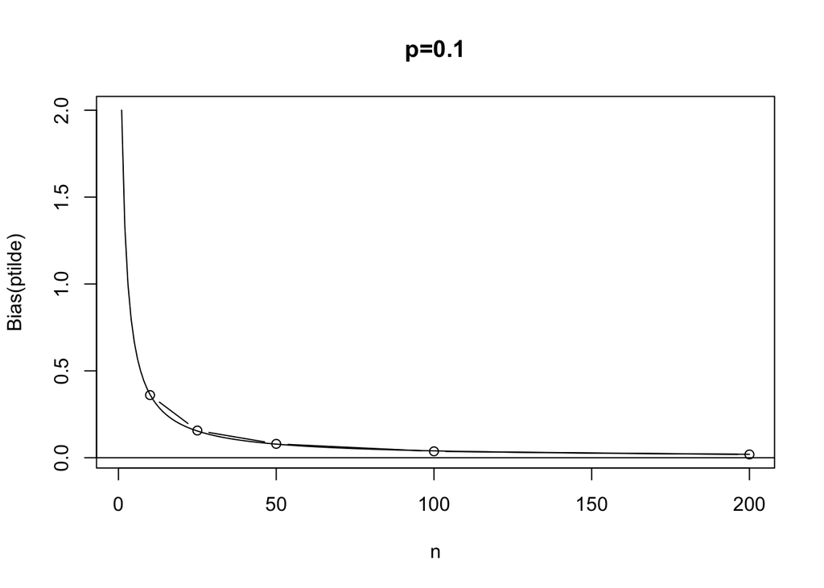

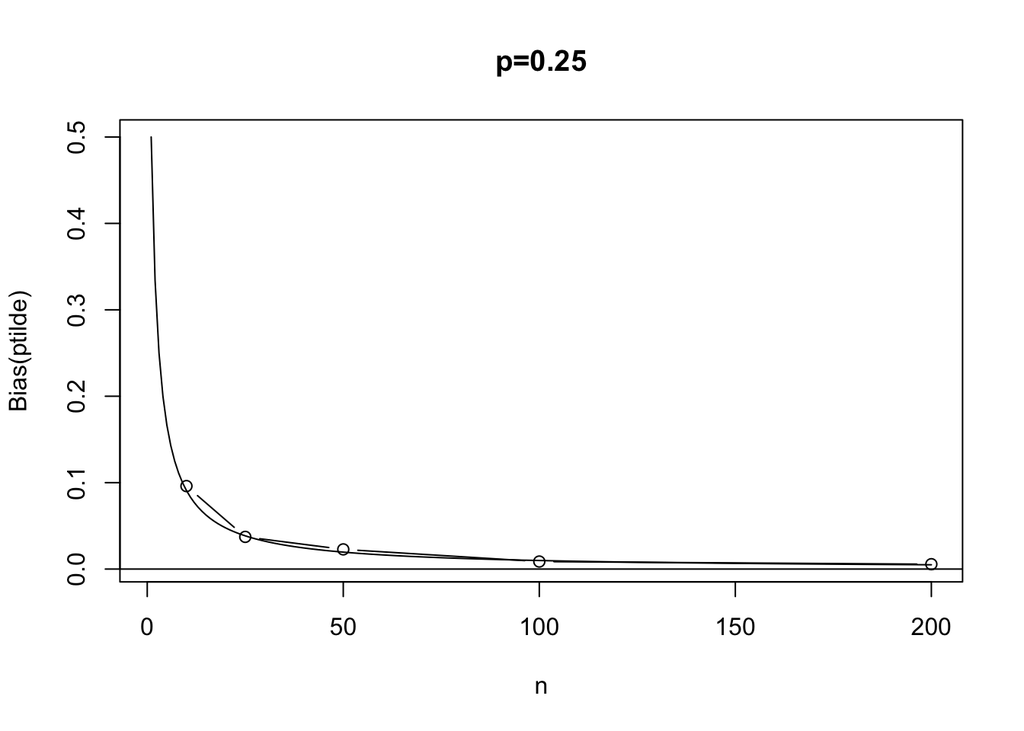

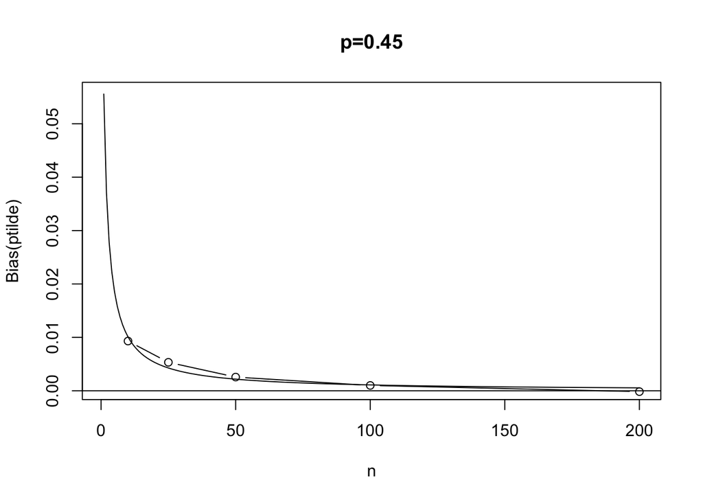

```r
nsim = 10000
n = 1:200
ns = c(10, 25, 50, 100, 200)
ps = c(0.01, 0.1, 0.25, 0.45)
for(p in ps){
  # sample data for each sample size
  samps = replicate(nsim, {(rbinom(length(ns), size = ns, p) + 1/2)/(ns+1)} )
  # take mean across simulations
  simBias = rowMeans(samps) - p

  ptildeBias = (n * p + 0.5)/(n+1) - p
  # divide by p for percent bias
  plot(n, ptildeBias/p, xlab='n', ylab='Bias(ptilde)', type='l', main=paste0('p=',p) )
  points(ns, simBias/p, type='b')
  abline(h=0)
}
```

## Confidence intervals for a mean

Today we will:

- Introduce a confidence interval for normally distributed data
- We will use spinal cord imaging to study these confidence intervals
- We will run a simulation to understand what the confidence interval means about dataset-to-dataset variability

### Multiple sclerosis in the spinal cord

- [Seth Smith](https://vuiis.vumc.org/bio/seth.smith)’s research team is developing advanced spinal cord magnetic resonance imaging sequences to study multiple sclerosis (MS).
- These new sequences are making it possible to study the spinal cord in more detail through development and aging
- Today our research question is **What is the cross-sectional area of the C3 segment of the spinal cord?**

#### Spinal cord anatomy

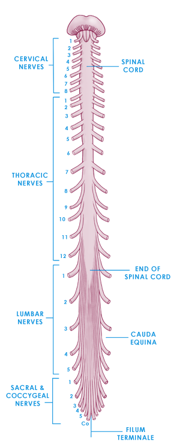

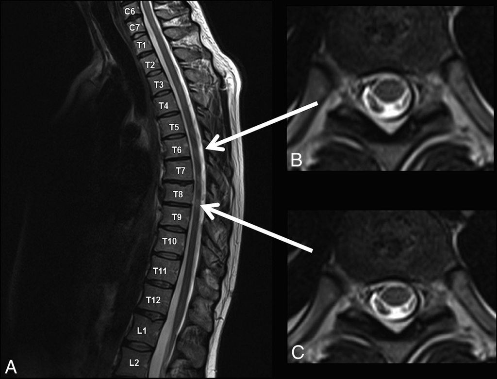

- The cord section we are looking at is cervical section C3 (near the top).
- Damage here affects a large portion of the body.

#### Seth’s interest in the spinal cord

- MS is a progressive disease associated with demyelination of neurons (reduces signaling efficiency) that has significant detriment on many aspects of daily life, with motor symptoms being the most common.
- MRI has almost exclusively focused on the brain in MS and associated MRI-derived brain lesion measures with severity of MS symptoms
- Seth pointed out to the MS community that there are lesions in the spinal cord that scientists haven’t paid as much attention to.

#### Characterization of the C3 cross-sectional area

- What random variable models might be appropriate for these data?

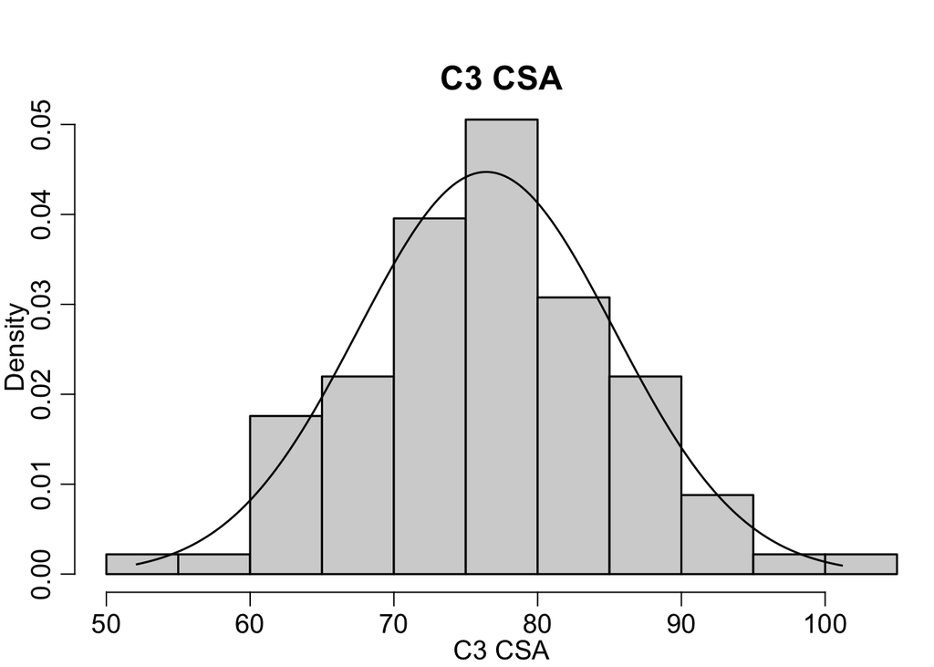

```r
load('../datasets/smith_cervical_sc/tpmf.rdata')

cex=1.5
par(mgp=c(1.7,.7,0), lwd=1.5, lend=2, cex.lab=0.8*cex, cex.axis=0.8*cex, cex.main=1*cex, mfrow=c(1,1), mar=c(2.8,2.8,1.8,.2), bty='l', oma=c(0,0,2,0))
# histogram of C3 CSA
hist(mf$`C3 CSA`, main='C3 CSA', xlab='C3 CSA', freq=F)
lines(seq(min(mf$`C3 CSA`), max(mf$`C3 CSA`), length.out=200), dnorm(seq(min(mf$`C3 CSA`), max(mf$`C3 CSA`), length.out=200), mean = mean(mf$`C3 CSA`), sd = sd(mf$`C3 CSA`)))
```

- What is a good model for these data?

#### CIs conceptually

The concept of a CI highlights the distinction between a parameter, estimate, and estimator.

- What is the parameter?
- What is an estimate of the parameter?
- What is an estimator of the parameter, notationally?

The concept of an estimator allows us to make probabilistic statements about the procedures we execute in our dataset.

### Confidence interval definition

- Confidence intervals are an interval obtained from a sample that contains the true value of the parameter with a given probability.
  $$P\{L(X_1, \ldots, X_n) \le p < U(X_1, \ldots, X_n) \} = 1-\alpha,$$
  for a given value $\alpha \in (0,1)$.
- Note what things are random here (the end points). The parameter is fixed.

### Known variance confidence interval for the mean

- Let’s assume our spinal cord data $X_1, \ldots X_n \sim N(\mu, \sigma^2)$ are IID and normally distributed.
- The empirical mean is an estimator for this value
  $$\hat\mu = n^{-1}\sum_{i=1} X_i.$$
- Let’s (unrealistically) assume that $\sigma^2$ is known.

#### The interval derivation

- The sum of IID normals is normal $N(\mu, \sigma^2/n)$.
- This is *exact* (not an approximation).
- What is the distribution of $\sqrt{n}(\hat\mu - \mu)/\sigma$?
- We can construct an $\alpha$ probability confidence interval for $\mu$ using this fact.
  $$\begin{align*}
  \P(z_{\alpha/2} < Z < z_{1-\alpha/2} ) &
  = \Phi(z_{1-\alpha/2}) - \Phi(z_{\alpha/2} ) \\
  & = 1-\alpha/2 - \alpha/2\\
  &= 1-\alpha
  \end{align*}$$

So we can create the interval
$$\begin{align*}
\P(z_{\alpha/2} < Z < z_{1-\alpha/2} )
& = \P(z_{\alpha/2} < \sqrt{n}(\hat\mu - \mu)/\sigma <
z_{1-\alpha/2} )
\end{align*}$$

## Computing confidence intervals

- Recap of constructing normal confidence interval
- Computing the confidence interval in the spinal cord data

### Constructing the confidence interval in the Spinal cord data set

```r
x = mf$`C3 CSA`
alpha = 0.01

# get n
n = length(x)
# get the mean
muHat = mean(x)
# get the sd
stdev = sqrt(var(x)) # sd(x)
# get z_alpha/2 and z_(1-alpha/2)
qnorm(1-alpha/2)
```

```
## [1] 2.575829
```

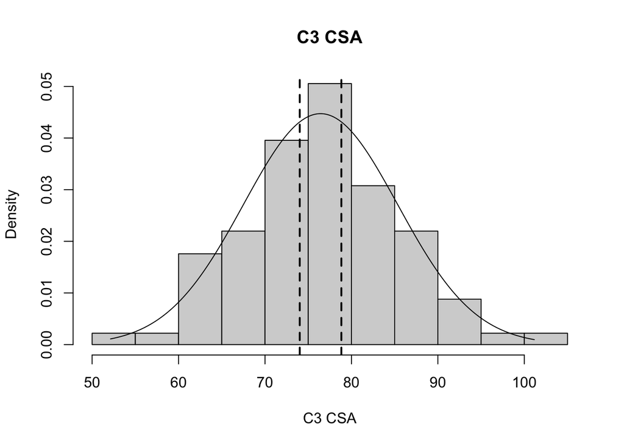

```r
zalpha = qnorm(1- alpha/2)
# construct the interval
interval = c(muHat - zalpha * stdev /sqrt(n), muHat + zalpha * stdev /sqrt(n) )

hist(mf$`C3 CSA`, main='C3 CSA', xlab='C3 CSA', freq=F)
lines(seq(min(mf$`C3 CSA`), max(mf$`C3 CSA`), length.out=200), dnorm(seq(min(mf$`C3 CSA`), max(mf$`C3 CSA`), length.out=200), mean = mean(mf$`C3 CSA`), sd = sd(mf$`C3 CSA`)))
abline(v=interval, lty=2, lwd=2)
```

```r
# What is the interpretation of this interval
```

1. The mean in my data set, $\bar X_n$, lies within this interval with probability 1-alpha.
2. This interval contains the true mean parameter with probability 1-alpha.
3. The procedure we used to create this interval captures the mean parameter 1-alpha% of the time.
4. Across a large number of samples, approximately (1-alpha)% of the intervals will contain the true value of the parameter.

### Dataset-to-dataset variability

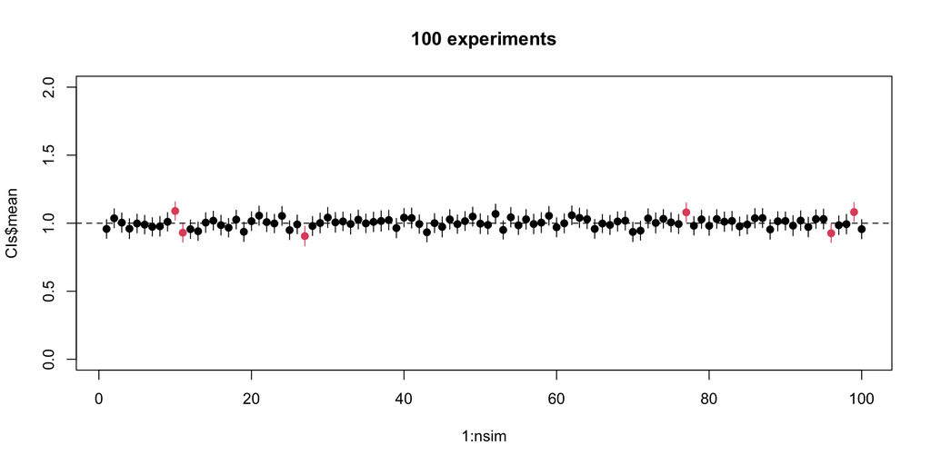

```r
mu = 1
sigma = 0.8
n = 500
nsim = 100
alpha = 0.05
CIs = data.frame(mean=rep(NA, nsim), lower=rep(NA, nsim), upper=rep(NA, nsim))
for(sim in 1:nsim){
  # draw a random sample
  X = rnorm(n, mean=mu, sd=sigma)
  stdev = sd(X)
  # construct the confidence interval
  CIs[sim, ] = c(mean(X), mean(X) + c(-1,1)*qnorm(1-alpha/2)*stdev/sqrt(n))
}
CIs$gotcha = ifelse(CIs$lower<=mu & CIs$upper>=mu, 1, 2)
# range(c(CIs$lower, CIs$upper))
plot(1:nsim, CIs$mean, pch=19, ylim = c(0,2), main=paste(nsim, 'experiments'), col=CIs$gotcha )
segments(x0=1:nsim, y0=CIs$lower, y1=CIs$upper, col=CIs$gotcha)
abline(h=mu, lty=2 )
```

### Estimating the variance

- Almost always, the variance of the data is unknown.
- We need an estimate of $\sigma^2$ from the data. Two are common
  $$\begin{align*}
  \tilde \sigma^2 & = n^{-1} \sum_{i=1}^n X_i \text{ (maximum
  likelihood estimator)}\\
  \hat \sigma^2 & = (n-1)^{-1} \sum_{i=1}^n X_i \text{ (unbiased
  estimator)}\\
  \end{align*}$$
- We’ll focus on the second estimator.

### Unknown variance approximate interval

- What is the distribution of $\sqrt{n}(\hat\mu - \mu)/\tilde\sigma$?
- If we don’t know the distribution, then there is theoretical justification (using Slutsky’s theorem) to say
  $$\sqrt{n}(\hat\mu - \mu)/\hat\sigma \sim N(0,1) \text{ (approximately)}$$
- Approximately means *asymptotically*, which means that if we can control how big our sample is, then we can make this approximation as precise as we want by choosing a big enough sample size.
- This suggests a confidence interval
  $$\hat \mu \pm z_{\alpha/2} \times \hat\sigma/\sqrt{n}.$$

## T- confidence interval

Today we will:

- Find an exact interval for the mean when the data are normally distributed
- Compare the intervals we’ve derived, so far
- Discuss our assumptions and learn how to assess the assumptions

### Unknown variance T-interval

We need some preliminaries:

- If $Z_i \sim N(0, 1)$ are iid, then (by definition) $X = \sum_{i=1}^{(n-1)}Z_i^2$ is [Chi-squared distributed](https://en.wikipedia.org/wiki/Chi-square_distribution) on $(n-1)$ degrees of freedom. Usually denoted $X\sim \chi^2(n-1)$.
- If $Z \sim N(0, 1)$ and $X\sim \chi^2(n-1)$ are independent, then
  $$T = \frac{Z}{\sqrt{X/(n-1)}} \sim t(n-1).$$
  where $t(n-1)$ denotes the t-distribution on $n-1$ degrees of freedom.

#### How does this help us and what does it have to do with beer?

We already know that,
$$\sqrt{n}(\bar X - \mu)/\sigma \sim N(0,1).$$
It turns out that
$$(n-1)\hat \sigma^2/\sigma^2 \sim \chi^2(n-1),$$
and (surprisingly!) $\hat \sigma^2$ and $\bar X$ are independent! (Which implies that the two random variables above are also independent)

Then the test statistic we’ve been working with is
$$\sqrt{n}(\hat\mu - \mu)/\hat\sigma = \sqrt{n}(\hat\mu - \mu)/\sigma
\times \sqrt{\frac{\sigma^2}{\hat\sigma^2} }
=_D Z \times \sqrt{\frac{n-1}{X}} =_D T,$$
$Z \sim N(0, 1)$ and $X\sim \chi^2(n-1)$, and $T\sim t(n-1)$

This is the one-sample t-test (or confidence interval).

#### But what does it have to do with beer!?!?

William Gossett published the t-test when he was working for Guinness and was required to publish under a pseudoname. [Wikipedia has more](https://en.wikipedia.org/wiki/William_Sealy_Gosset).

[figure not shown]

Guinness

#### Possible intervals (so far)

Here are our intervals then

$$\begin{align*}
\hat \mu \pm z_{\alpha/2} \times \sigma/\sqrt{n} \\
\hat \mu \pm z_{\alpha/2} \times \hat\sigma/\sqrt{n} \\
\hat \mu \pm t_{n-1,\alpha/2} \times \hat\sigma/\sqrt{n}.
\end{align*}$$

```r
x = mf$`C3 CSA`
alpha = 0.01

# get n
n = length(x)
# get the mean
muHat = mean(x)
# get the sd
stdev = sqrt(var(x)) # sd(x)
# get z_alpha/2 and z_(1-alpha/2)
qnorm(alpha/2)
```

```
## [1] -2.575829
```

```r
zalpha = qnorm(1- alpha/2)
talpha = qt(1-alpha/2, n-1)
qt(alpha/2, n-1)
```

```
## [1] -2.631565
```

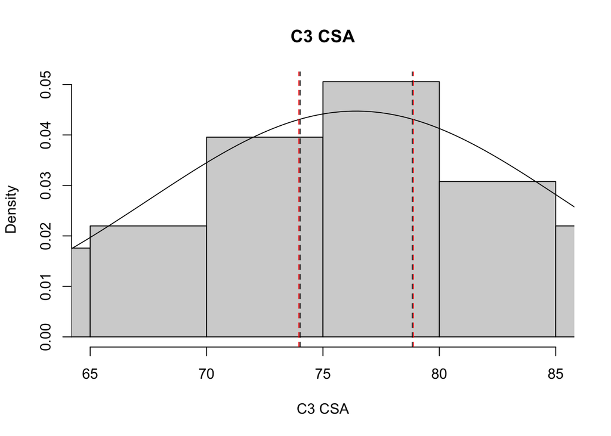

```r
# construct the interval
Zinterval = c(muHat - zalpha * stdev /sqrt(n), muHat + zalpha * stdev /sqrt(n) )
Tinterval = c(muHat - talpha * stdev /sqrt(n), muHat + talpha * stdev /sqrt(n) )

hist(mf$`C3 CSA`, main='C3 CSA', xlab='C3 CSA', freq=F, xlim=c(65,85))
lines(seq(min(mf$`C3 CSA`), max(mf$`C3 CSA`), length.out=200), dnorm(seq(min(mf$`C3 CSA`), max(mf$`C3 CSA`), length.out=200), mean = mean(mf$`C3 CSA`), sd = sd(mf$`C3 CSA`)))
abline(v=Zinterval, lty=2)
abline(v=Tinterval, lty=2, col='red')
```

```r
# What is the interpretation of this interval
```

## Evaluating confidence intervals

- Review assumptions of our three intervals so far.
- Weaken the assumptions a little bit more.
- Assess confidence intervals using simulations.

### Checking assumptions

What assumptions have we made for what reason?

We can relax two of these at the expense of having approximate intervals.

### Checking assumptions: Q-Q plot

- A Q-Q plot compares the distribution of the observed data (sample quantiles) compared to the theoretical distribution (here a standard normal)
- Rank the data and normalize
  - $y_i = (x_{(i)}/ - \bar x)/{\tilde \sigma}$
  - Plot is `x=qnorm(i/n)`, `y=y_i`.
  - If data are normal the points will be on the line
- Check out more details on [Wikipedia](https://en.wikipedia.org/wiki/Q%E2%80%93Q_plot)
- These data are surprisingly close to a normal distribution!

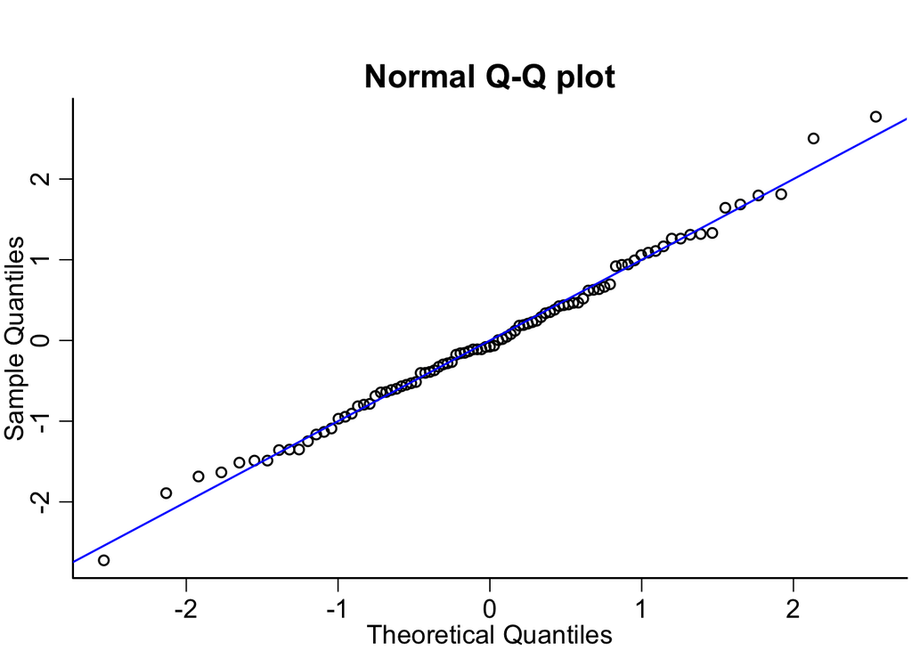

```r
cex=1.5
par(mgp=c(1.7,.7,0), lwd=1.5, lend=2, cex.lab=0.8*cex, cex.axis=0.8*cex, cex.main=1*cex, mfrow=c(1,1), mar=c(2.8,2.8,1.8,.2), bty='l', oma=c(0,0,2,0))
qqnorm(scale(mf$`C3 CSA`), main='Normal Q-Q plot')
abline(a=0, b=1, col='blue')
```

### Review of what we just did so far

1. We identified a parameter of interest (population mean of C3 CSA).
2. We made some assumptions about the data.
3. We identified three Frequentist confidence intervals.

### Aside: What is the interpretation of these intervals?

$$\P(\hat \mu - z_{\alpha/2} \times \hat\sigma/\sqrt{n} < \mu < \hat
\mu + z_{\alpha/2} \times \hat\sigma/\sqrt{n}) \approx 1-\alpha$$
…this interpretation is all of Frequentist statistics.

#### Relaxing assumptions (normality and identicality)

- There’s one theorem we mentioned in class last week that can relax both of these assumptions
- This suggests that we can basically reduce our assumptions to independence and finite variance (and the extra condition in the theorem).
- Then we can use this interval a lot of the time:
  $$\P(\hat \mu - z_{\alpha/2} \times \hat\sigma/\sqrt{n} < \mu < \hat
  \mu + z_{\alpha/2} \times \hat\sigma/\sqrt{n}) \approx 1-\alpha$$
- This depends on 2 approximations:
  1. Large sample (*asymptotic*) normality of the mean
  2. “plugging-in” $\hat\sigma$ for the unknown parameter $\sigma$.
- In practice, it seems that it’s always safer to use the T- distribution over the normal distribution for confidence intervals (more on this later)

## Evaluating confidence intervals under assumption violations

Today we will:

- Estimate a confidence interval in the C3 cross sectional data
- Run simulations to assess performance of confidence intervals
  - You can use this code to run your simulations for homework 3
- Check how sensitive our confidence intervals are to assumptions
- Define some confidence intervals for the binomial proportion

### Confidence intervals for the mean in the spinal cord data set

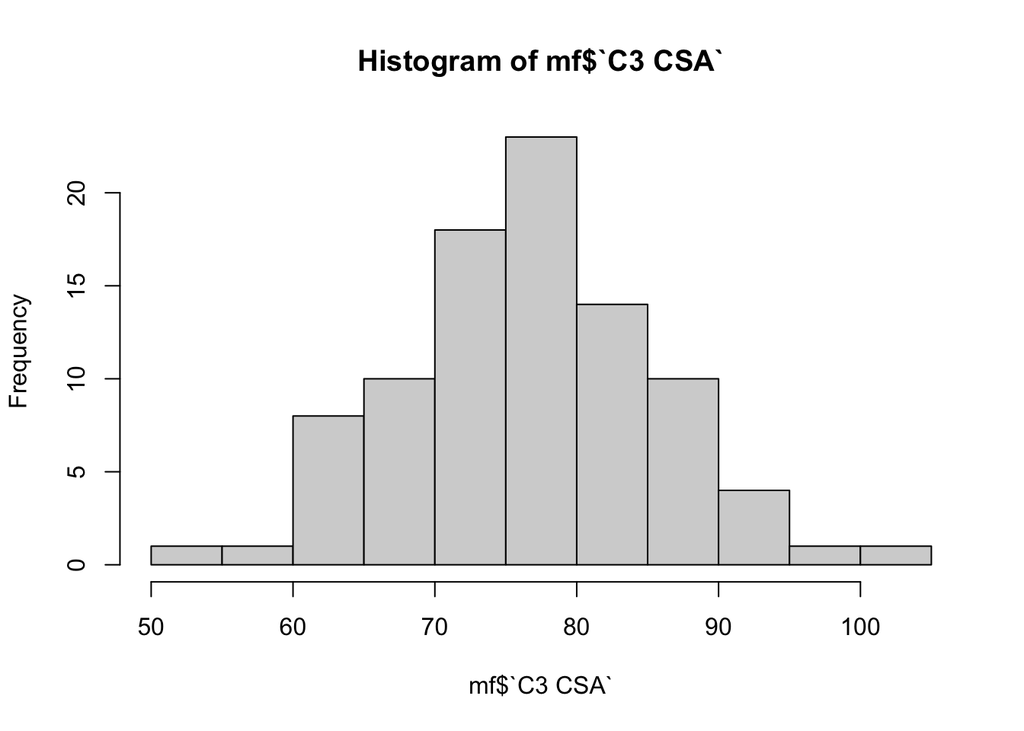

```r
hist(mf$`C3 CSA`)
```

```r
t.test(mf$`C3 CSA`)
```

```
##
##  One Sample t-test
##
## data:  mf$`C3 CSA`
## t = 81.738, df = 90, p-value < 2.2e-16
## alternative hypothesis: true mean is not equal to 0
## 95 percent confidence interval:
##  74.56922 78.28441
## sample estimates:
## mean of x
##  76.42682
```

```r
m = mean(mf$`C3 CSA`)
n = nrow(mf)
df = n-1
stdev = sd(mf$`C3 CSA`)
m
```

```
## [1] 76.42682
```

```r
df
```

```
## [1] 90
```

```r
# alpha = 0.05
m + c(-1, 1)*qt(0.975, df = df)*stdev/sqrt(n)
```

```
## [1] 74.56922 78.28441
```

$$\begin{align*}
\hat \mu \pm z_{\alpha/2} \times \sigma/\sqrt{n} \text{ (don't know
sigma)} \\
\hat \mu \pm z_{\alpha/2} \times \hat\sigma/\sqrt{n} \\
\hat \mu \pm t_{n-1,\alpha/2} \times \hat\sigma/\sqrt{n}.
\end{align*}$$

This interval $\hat \mu \pm t_{n-1,\alpha/2} \times \hat\sigma/\sqrt{n}$ is approximate/exact. What are the assumptions?

This interval $\hat \mu \pm z_{\alpha/2} \times \hat\sigma/\sqrt{n}$ is approximate/exact. Assuming you are using the central limit theorem, the assumptions are

### Simulation setup

- We run simulations to evaluate the confidence intervals in finite samples.
- What are the metrics we care about, here?
  1. **Coverage** – an $\alpha$ level Frequentist interval should contain the true parameter at least $1-\alpha$ percent of the time.
  2. **Width** – a smaller interval (that has the right coverage) is better.
- How do we setup the simulations?
  - We have a few variables we can set: $n$, $\mu$, $\sigma^2$, $\alpha$, number of simulations.
  - Need a way to sample the data $X_i$ given $n$, $\mu$, and $\sigma^2$.
  - Need a function to construct the CIs given the sample.
  - Need a function to assess the coverage and width of the confidence intervals.
  - Need a way to assess violations of normality.
  - Need to do simulations for some different values of some of the parameters.
  - Need to create some nice looking plots for the results.

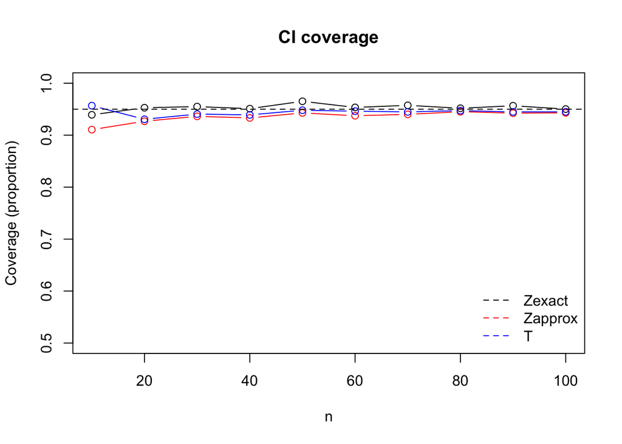

```r
mu = 1
sigma = 1
ns = (1:10) * 10
nsim = 5000
alpha = 0.05

# to simulate the null in the ECT data
ect = read.csv('../datasets/ect/ect.csv')
ECT = ect$cgi.i
mu = mean(ECT)
sigma = sd(ECT)

simResults = data.frame(n = ns)
simResults[ , c('Zexact_coverage', 'Zapprox_coverage', 'T_coverage', 'Zexact_width', 'Zapprox_width', 'T_width')] = NA

for(n in ns){
  CIs = data.frame('mean' = rep(NA, nsim))
  CIs[, paste(rep(c('Zexact', 'Zapprox', 'T'), each=2), rep(c('lower', 'upper'), 3), sep="_" )] = NA

  for(sim in 1:nsim){
    # draw a random sample, normal or skewed
    X = sample(ECT, n, replace=TRUE) #mu +  (rgamma(n, shape = 1.2, rate = 5) - 1.2/5)/sqrt(1.2)*5 # rnorm(n, sd=sigma) #  # sample(n, fakeECT, replace=TRUE)
    stdev = sd(X)
    # construct the Zexact confidence interval
    CIs$mean[sim] = mean(X)
    CIs[sim, c('Zexact_lower', 'Zexact_upper') ] = c(mean(X) + c(-1,1)*qnorm(1-alpha/2)*sigma/sqrt(n))
    # construct two more CIs
    # Z approximate interval
    CIs[sim, c('Zapprox_lower', 'Zapprox_upper') ] = c(mean(X) + c(-1,1)*qnorm(1-alpha/2)*stdev/sqrt(n))
    # T-interval
    CIs[sim, c('T_lower', 'T_upper') ] = c(mean(X) + c(-1,1)*qt(1-alpha/2, n-1)*stdev/sqrt(n))
  }
  CIs$Zexact_gotcha = ifelse(CIs$Zexact_lower<=mu & CIs$Zexact_upper>=mu, 1, 0)
  CIs$Zapprox_gotcha = ifelse(CIs$Zapprox_lower<=mu & CIs$Zapprox_upper>=mu, 1, 0)
  CIs$T_gotcha = ifelse(CIs$T_lower<=mu & CIs$T_upper>=mu, 1, 0)
  # This computing the width of the confidence interval
  CIs[paste(c('Zexact', 'Zapprox', 'T'), 'width', sep="_")] = CIs[, grep('_upper', names(CIs))] -  CIs[, grep('_lower', names(CIs))]

  simResults[which(simResults$n==n), grep('coverage', names(simResults), value = TRUE)] = colMeans(CIs[ , grep('_gotcha', names(CIs), value=TRUE) ] )
  simResults[which(simResults$n==n), grep('width', names(simResults), value = TRUE)] = colMeans(CIs[ , grep('_width', names(CIs), value=TRUE) ] )
}

plot(simResults$n, simResults$Zexact_coverage, ylim=c(0.5, 1), type='b', ylab='Coverage (proportion)', xlab='n', main='CI coverage')
points(simResults$n, simResults$Zapprox_coverage, type='b', col='red')
points(simResults$n, simResults$T_coverage, type='b', col='blue')
abline(h=1-alpha, lty=2)
legend('bottomright', legend=c('Zexact', 'Zapprox', 'T'), col=c('black', 'red', 'blue'), bty='n', lty=2)
```

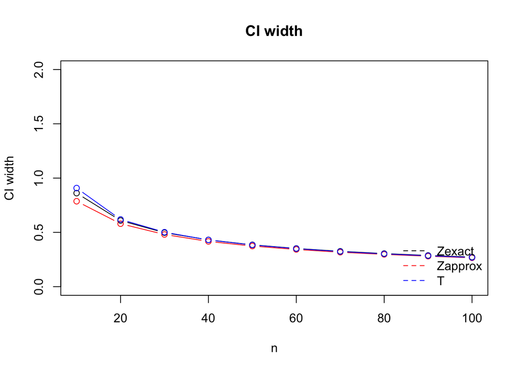

```r
plot(simResults$n, simResults$Zexact_width, type='b', ylim=c(0, 2), ylab='CI width', xlab='n', main='CI width')
points(simResults$n, simResults$Zapprox_width, type='b',  col='red')
points(simResults$n, simResults$T_width, type='b', col='blue')
legend('bottomright', legend=c('Zexact', 'Zapprox', 'T'), col=c('black', 'red', 'blue'), bty='n', lty=2)
```

```r
# range(c(CIs$lower, CIs$upper))
```

- Don’t interpret width without having proper coverage.
- These estimates are noisy, just like the bias/variance simulations. Use more to get better estimates.
- Rerun these simulations with the gamma errors. With errors from ECT data

## T-test in another data set

- Another collaborator I have is evaluating the effect of ECT to treat depression and psychosis symptoms.
- For this study, my collaborator has reported [CGI-I scores](https://simpleandpractical.com/clinical-global-impressions-scale-cgi/)
- The value 4 represents “no change” and he wants to know whether the population mean is likely to be far from 4.

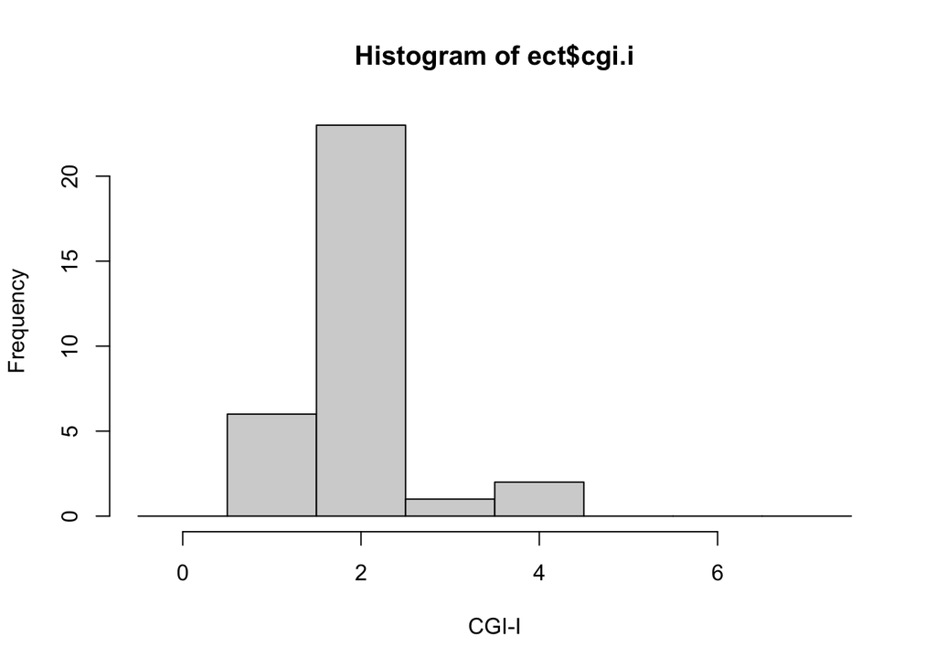

```r
hist(ect$cgi.i, xlab='CGI-I', breaks = c(0:8)-0.5)
```

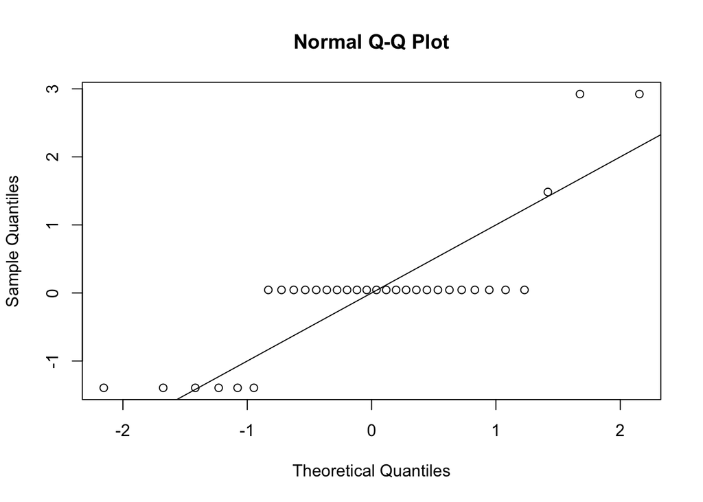

```r
qqnorm(scale(ect$cgi.i)); abline(a=0, b=1)
```

```r
ect$cgi.i - mean(ect$cgi.i)
```

```
##  [1]  0.03125  0.03125  0.03125  0.03125  0.03125  0.03125 -0.96875  0.03125
##  [9]  0.03125  0.03125  0.03125  1.03125  0.03125  0.03125  0.03125  0.03125
## [17]  2.03125 -0.96875 -0.96875  0.03125 -0.96875  0.03125  0.03125 -0.96875
## [25]  0.03125  2.03125  0.03125  0.03125  0.03125  0.03125  0.03125 -0.96875
```

```r
t.test(ect$cgi.i)
```

```
##
##  One Sample t-test
##
## data:  ect$cgi.i
## t = 16.027, df = 31, p-value < 2.2e-16
## alternative hypothesis: true mean is not equal to 0
## 95 percent confidence interval:
##  1.718218 2.219282
## sample estimates:
## mean of x
##   1.96875
```

## Confidence intervals for binomial proportions

### CIs using the central limit theorem

Remember the CLT:

**The Central Limit Theorem (Durrett, pg. 124):** Let $X_1, X_2, \ldots$ be iid with $\E X_i = \mu$ and $\text{Var}(X_i) = \sigma^2 \in (0, \infty)$.

If $\bar X_n = n^{-1} \sum_{i=1}^n X_i$, then
$$n^{1/2}(\bar X_n - \mu)/\sigma \to_D X,$$
where $X \sim N(0,1)$.

- The CLT allows us to make probabilistic statements about estimators that can be expressed as sums.
- Since it is an “asymptotic” approximation (infinite sample size), we don’t know how it works in finite samples.
- Most often, we use simulations to evaluate the finite sample approximation.
- For homework Problem 1a you will derive this interval, just like we do here.

$$\mathbb{P}\left(\bar X_n - Z_{0.975}\times \sqrt{p(1-p)/n} < p <
\bar X_n + Z_{0.975}\times \sqrt{p(1-p)/n}\right) \approx 0.95.$$

**You will work with this interval for homework**

### Clopper-Pearson interval for the binomial proportion

- This is an *exact* interval (sort of), meaning the probability of coverage is not approximate.
- To me, it’s not intuitive why this works as a confidence interval ([Clopper. Pearson](https://academic.oup.com/biomet/article-abstract/26/4/404/291538?redirectedFrom=fulltext)).

Conditional on the value $X_o \sim \text{Binom}(p)$ (treat it as nonrandom), define $p_\ell(X_o)$ as the value that satisfies
$$0.975 = \sum_{k=0}^{X_o-1}{ n \choose k} p_{\ell}^k(1-p_\ell)^{n-k}$$
and $p_u(X_o)$ as the value that satisfies
$$0.025 = \sum_{k=0}^{X_o}{ n \choose k} p_{u}^k(1-p_u)^{n-k}$$

### Picture of this interval

Let’s say $n=50$, $\sum_i x_i = 30$, then choose $p$ so that

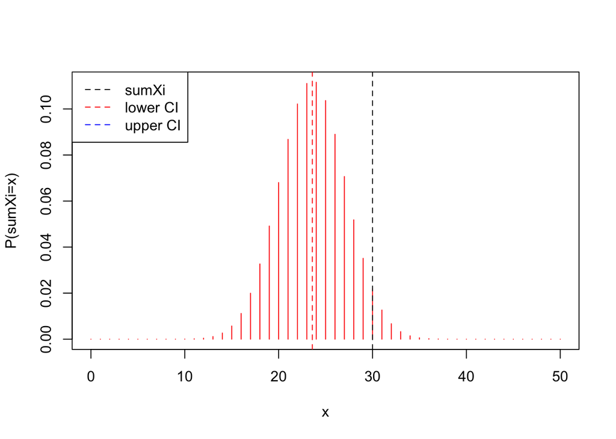

```r
n=50
si = 30
alpha = 0.05
x = 0:n
plower = uniroot(function(p) pbinom(si, n, p) - (1-alpha/2), interval=c(0.1, 0.9))$root
pupper = uniroot(function(p) pbinom(si, n, p) - alpha/2, interval=c(0.1, 0.9))$root
yl = dbinom(x, size=n, prob=plower)
yu = dbinom(x, size=n, prob=pupper)

plot(x, yl, ylab='P(sumXi=x)', xlab='x', type='h', col='red')
abline(v=si, col='black', lty=2)
abline(v=plower*n, col='red', lty=2)
legend('topleft', legend=c('sumXi', 'lower CI', 'upper CI'), lty=2, col=c('black', 'red', 'blue'))
```

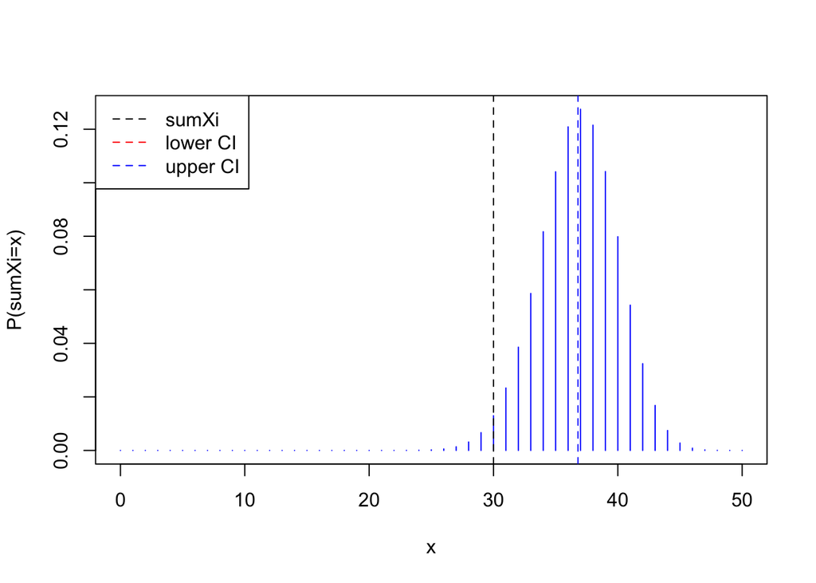

```r
plot(x, yu, ylab='P(sumXi=x)', xlab='x', type='h', col='blue')
abline(v=si, col='black', lty=2)
abline(v=pupper*n, col='blue', lty=2)
legend('topleft', legend=c('sumXi', 'lower CI', 'upper CI'), lty=2, col=c('black', 'red', 'blue'))
```

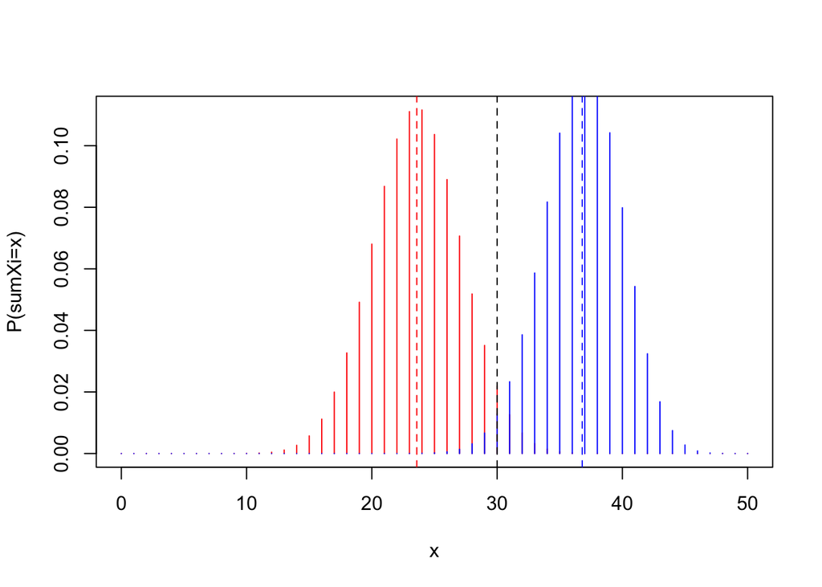

```r
plot(x, yl, ylab='P(sumXi=x)', xlab='x', type='h', col='red')
points(x, yu, type='h', col='blue')
abline(v=si, col='black', lty=2)
abline(v=plower*n, col='red', lty=2)
abline(v=pupper*n, col='blue', lty=2)
```

- Picture of the interval.

### Beta distribution

The Beta distribution is a two parameter distribution
$$f(y; \alpha, \beta) = \frac{1}{B(\alpha,
\beta)}y^{\alpha-1}(1-y)^{\beta-1}.$$
Note its similarity to the binomial distribution
$$p^{\sum_i x_i}(1- p)^{n-\sum_i x_i}$$

It turns out that this duality implies that the boundaries for the Clopper-Pearson interval can be expressed in terms of quantiles of the beta distribution
$$\left(\text{qbeta}(\alpha/2, X, n-X +1),
\text{qbeta}(1-\alpha/2, X+1, n-X) \right)$$

## Extra stuff

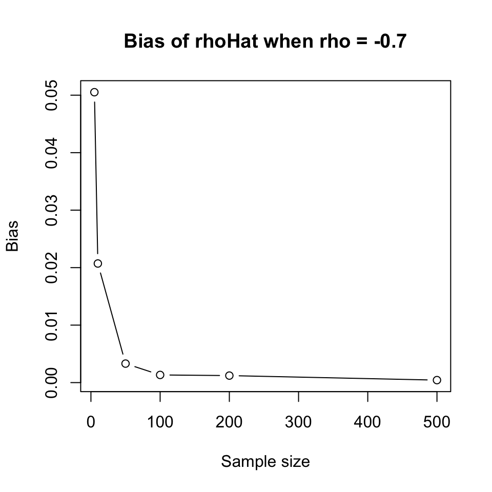

```r
# sample size
ns = c(5, 10,50,100,200,500)
# correlation
rhos = c(0, -0.7)


# creating blank output table
results = expand.grid(rho=rhos , n=ns)
colNames = paste(rep(c("rhoHat"), each=3),
                 rep(c('Bias', 'Variance', 'MSE'), 1))
results[, colNames ] = NA



for(simInd in 1:nrow(results)){
  rho = results[simInd,'rho']
  n = results[simInd, 'n']

  # generate data
  Sigma = matrix(c(1, rho, rho, 1), nrow=2)
  sqrtSigma = svd(Sigma)
  sqrtSigma = sqrtSigma$u %*% diag(sqrt(sqrtSigma$d))
  # each column is a draw of x and y

  rhoHats = replicate(n = 10000,  cor(tcrossprod(matrix(rnorm(n*2),
            ncol=2), sqrtSigma)))

 # compute bias, variance, MSE of estimators
 results[simInd, c('rhoHat Bias', 'rhoHat Variance')]=
   c(mean(rhoHats[1,2,])-rho , var(rhoHats[1,2,]))
}

subres = results[results$rho== -0.7, ]
subres2 = results[results$rho== 0,]


plot(subres$n, subres$`rhoHat Bias`, xlab='Sample size', ylab='Bias',
     main='Bias of rhoHat when rho = -0.7', type='b')
```

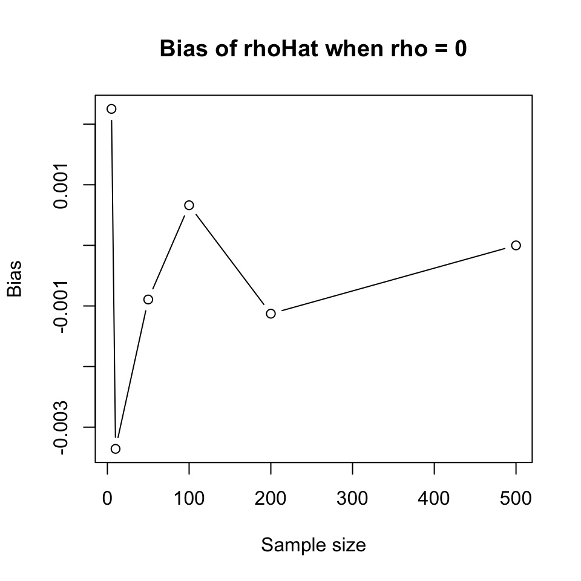

```r
plot(subres2$n, subres2$`rhoHat Bias`, xlab='Sample size', ylab='Bias',
     main='Bias of rhoHat when rho = 0', type='b')
```